# Chapter 2 - Sequential and Simulated T-tests with ROPE

Mark Gallacher

2022-11-04

### **Chapter 0** : Setting up some Parametres and Loading in Librarys + Functions

```r
library(tidyverse)
## setting relative directory
here::i_am("./notebook/Chapter_2_T-tests.Rmd")
```

```
## here() starts at D:/source/repo/psy-project
```

```r
source(file = here::here("my-scripts", "R", "t_test_loop_functions.R"))

source(file = here::here("my-scripts", "R", "project_themes.R"))
```

```r
base_size = 13  # for graphs

n = seq(5, 5000, length.out = 1000)
l_n = length(n)

alphas = c(0.05, 0.01, 0.005, 0.001, 0.0005)
l_a = length(alphas)

repeats = 1000
```

### **Chapter 1** : Introducing Sequential Testing and the ROPE

In Null hypothesis significant testing (NHST) the standard practice is to construct a pseudo-hypothesis which represents the absence of an effect. This is typically done by stating the mean difference between the two groups would be 0. However, this “nil hypothesis” is not immune to noise in the dataset and would allow theoretically and practically irrelevant differences to reject the null hypothesis. One procedure to counter this it the ROPE, the region of practical equivalence, where we extend the values which represent the null to include values which would likely have little to no benefit in a practical setting. In other words, where the effect observed is simply too small to be useful.

To display how the ROPE could be useful, Kruschke (2013) used sequential t-tests to produce false positives with the NHST and Bayesian framework. Sequentially testing begins with small sample sizes but increases only if the result is not significant, else it would stop the procedure at that sample size. Significant is defined in his paper as p value of less than 0.05 and a Bayes Factor of 3 and 1/3 (to support alternative hypothesis and the null hypothesis respectively).

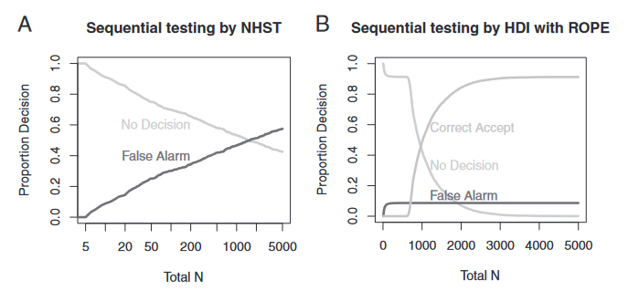

“Figure A: From Kruschke (2013), where the null hypothesis signifcance testing (NHST) is compared to Bayesian approach, when the highest density inteval (HDI) is used with a region of practical equivalence (ROPE). The graphs display the inferences made at different sample sizes. For the NHST, the binary decision boundary returns a significant or non-significant difference between the two groups whereas Bayes Factors offer three options, supporting the null hypothesis, supporting the alternative or supporting neither. Sequential testing consistently provides False positives in the NHST framework, even at large sample sizes, whilst the bayesian approach appears to become more stable as sample size increases”

### **Chapter 2.1**: Generated Data is read into Document

Data was generated usinf sequential tests with a (Region of Practical Equivalence) ROPE with large margins to see more the extreme effects of the ROPE. The goal is to prevent the false positives that appear to naturally occur with sequential testing by preventing smaller effect rejecting the null hypothesis, especially when the null hypothesis is true.

Each procedure starts at the sample size of 5, in each group (generated from a normal distribution with a mean of 0 and sd of 1), then increases by 5 if the test returns a non-significant result (Where p value is less than alpha and the mean difference is greater than the margin). The Confidence interval was not used for simplicity but it may provide more information about the observed difference, ie if there is a good chance it is actually within the ROPE but the mean is slightly outside. This is repeated till we reach the sample size of 5000 in each group, or we get a significant result.

```r
# sequential t-tests - no rope - different alphas
seq_alphas <- read_csv(file = here::here("sim_data/ch2_t_tests", "seq_alphas.csv"))
# sequential t-test - one rope of 0.2, and different alphas
seq_rope_alphas <-  read_csv(file = here::here("sim_data/ch2_t_tests", "seq_rope_alphas.csv"))
# Sequential t-tests - with 5 Different ROPES
seq_rope_margins <- read_csv(file = here::here("sim_data/ch2_t_tests", "seq_rope_margins.csv"))

# simulating t-test - no rope - different alphas - with no effect
sim_alphas <- read_csv(file = here::here("sim_data/ch2_t_tests", "sim_alphas.csv"))
# simulating t-test - no rope - different alphas - with an effect
sim_diff_alphas <- read_csv(file = here::here("sim_data/ch2_t_tests", "sim_diff_alphas.csv"))
# simulating t-test - with ROPE - with no effect
sim_rope_margins <- read_csv(file = here::here("sim_data/ch2_t_tests", "sim_rope_margins.csv"))
# simulating t-test - with small ROPE - with no effect
sim_rope_small_margins <- read_csv(file = here::here("sim_data/ch2_t_tests", "sim_rope_small_margins.csv"))

head(seq_alphas)
```

```
## # A tibble: 6 × 7
##   alpha     n failed passed mean_diff   l_ci  u_ci
##   <dbl> <dbl>  <dbl>  <dbl>     <dbl>  <dbl> <dbl>
## 1  0.05    10  0.047  0.953     1.27  -0.952 1.10
## 2  0.05    20  0.033  0.967     0.982 -0.783 0.836
## 3  0.05    30  0.023  0.977     0.778 -0.782 0.596
## 4  0.05    40  0.014  0.986     0.656 -0.890 0.313
## 5  0.05    50  0.016  0.984     0.615 -0.940 0.192
## 6  0.05    60  0.019  0.981     0.538 -0.632 0.336
```

```r
head(seq_rope_alphas)
```

```
## # A tibble: 6 × 7
##   alpha     n failed passed mean_diff   l_ci  u_ci
##   <dbl> <dbl> <lgl>  <lgl>      <dbl>  <dbl> <dbl>
## 1  0.05    10 NA     NA         0.511 -1.45  1.40
## 2  0.05    20 NA     NA         0.363 -0.911 0.944
## 3  0.05    30 NA     NA         0.294 -0.735 0.752
## 4  0.05    40 NA     NA         0.245 -0.623 0.657
## 5  0.05    50 NA     NA         0.224 -0.580 0.554
## 6  0.05    60 NA     NA         0.203 -0.519 0.512
```

```r
head(seq_rope_margins)
```

```
## # A tibble: 6 × 7
##   margins     n failed passed mean_diff   l_ci  u_ci
##     <dbl> <dbl>  <dbl>  <dbl>     <dbl>  <dbl> <dbl>
## 1       0    10 0.053   0.947     1.31  -1.18  0.942
## 2       0    20 0.0346  0.965     0.958 -0.848 0.756
## 3       0    30 0.0254  0.975     0.773 -0.567 0.806
## 4       0    40 0.0182  0.982     0.679 -0.671 0.533
## 5       0    50 0.017   0.983     0.604 -0.570 0.501
## 6       0    60 0.0148  0.985     0.547 -0.453 0.539
```

```r
head(sim_alphas)
```

```
## # A tibble: 6 × 7
##    alpha     n failed passed mean_diff   l_ci  u_ci
##    <dbl> <dbl>  <dbl>  <dbl>     <dbl>  <dbl> <dbl>
## 1 0.0005    10 0.0002  1.00      0.511 -3.44  3.45
## 2 0.0005    20 0.0002  1.00      0.356 -1.87  1.86
## 3 0.0005    30 0.0012  0.999     0.288 -1.43  1.43
## 4 0.0005    40 0.0004  1.00      0.253 -1.20  1.19
## 5 0.0005    50 0.0006  0.999     0.228 -1.04  1.05
## 6 0.0005    60 0.0006  0.999     0.205 -0.941 0.951
```

```r
head(sim_diff_alphas)
```

```
## # A tibble: 6 × 7
##    alpha     n failed passed mean_diff  l_ci  u_ci
##    <dbl> <dbl>  <dbl>  <dbl>     <dbl> <dbl> <dbl>
## 1 0.0005    10 0.002   0.998     0.654 -3.95 2.94
## 2 0.0005    20 0.0056  0.994     0.565 -2.37 1.35
## 3 0.0005    30 0.0114  0.989     0.524 -1.92 0.930
## 4 0.0005    40 0.0224  0.978     0.521 -1.70 0.690
## 5 0.0005    50 0.0332  0.967     0.510 -1.55 0.548
## 6 0.0005    60 0.0512  0.949     0.509 -1.45 0.444
```

### **Chapter 2.2**: Tidying up Data

We are trying to see the accumulated number of tests that failed at a given sample size, as we start with 1000 tests, this number gradually decreases. This will help us produce a graph showing how many have returned significant results and how many are able to “survive” to the max sample size (5000 in each group).

The new column “prop”, for proportion, represents the this gradual increase in false positves. This is what is plotted later on, so it might be easier to understand these values by looking at the graphs in the next section.

Note: n now represents the total sample, as we start with 5 in each group and finish with 5,000, n now starts at 10 and ends at 10,000 (Total Sample).

```r
seq_alphas_df <- seq_alphas |>
  group_by(alpha) |>
  summarise(prop = cumsum(failed), n = n, .groups = "drop")
seq_rope_alphas_df <- seq_rope_alphas |>
  group_by(alpha) |>
  summarise(prop = cumsum(failed), n = n, .groups = "drop")
seq_rope_margins_df <- seq_rope_margins |>
  group_by(margins) |>
  summarise(prop = cumsum(failed), n = n, .groups = "drop")
head(seq_alphas_df)
```

```
## # A tibble: 6 × 3
##    alpha  prop     n
##    <dbl> <dbl> <dbl>
## 1 0.0005 0.001    30
## 2 0.0005 0.002    60
## 3 0.0005 0.003   120
## 4 0.0005 0.004   210
## 5 0.0005 0.005   390
## 6 0.0005 0.006   530
```

```r
head(seq_rope_alphas_df)
```

```
## # A tibble: 6 × 3
##    alpha  prop     n
##    <dbl> <int> <dbl>
## 1 0.0005    NA    10
## 2 0.0005    NA    20
## 3 0.0005    NA    30
## 4 0.0005    NA    40
## 5 0.0005    NA    50
## 6 0.0005    NA    60
```

```r
head(seq_rope_margins_df)
```

```
## # A tibble: 6 × 3
##   margins   prop     n
##     <dbl>  <dbl> <dbl>
## 1       0 0.053     10
## 2       0 0.0876    20
## 3       0 0.113     30
## 4       0 0.131     40
## 5       0 0.148     50
## 6       0 0.163     60
```

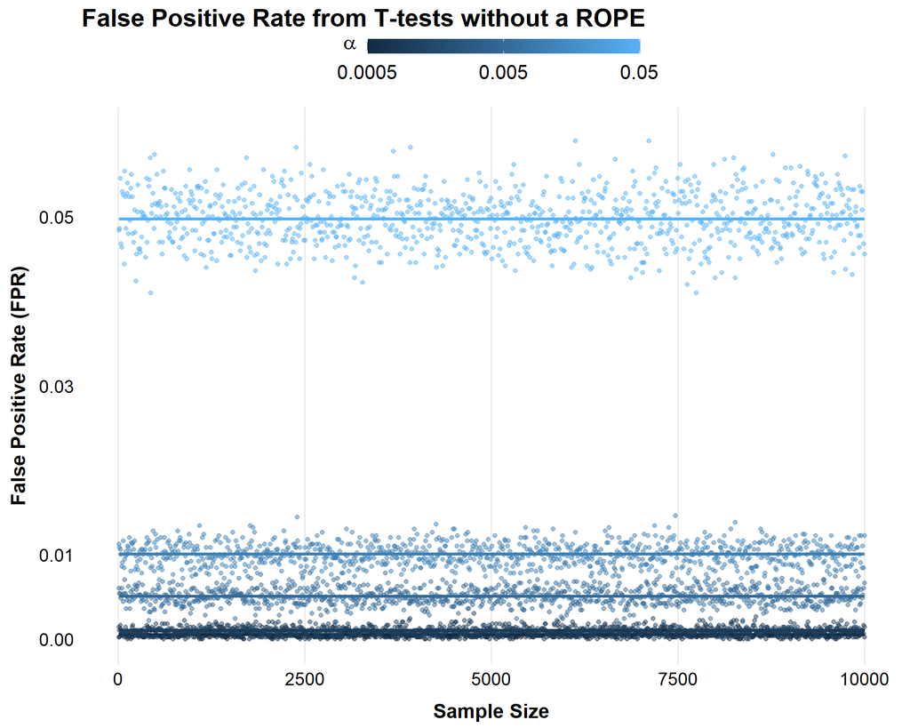

```r
sim_alphas |>
  group_by(alpha) |>
  mutate(f_prop = mean(failed)) |>
  ungroup() |>
  ggplot(aes(x = n, colour = alpha, group = alpha))+
  geom_line(aes(y = f_prop), linewidth = 1.2)+
  geom_point(aes(y = failed), alpha = .5)+
  scale_x_continuous("Sample Size")+
  scale_y_continuous("False Positive Rate (FPR)", limits = c(0, .06), breaks = c(0, 0.01, 0.03, 0.05))+
  scale_color_gradient(bquote(alpha),
                       guide = guide_colourbar(barwidth = 15, barheight = .8, title.vjust = 1),
                       trans = "log",
                       breaks = c(0.0005, 0.005, 0.05),
                       labels = c("0.0005", 0.005, 0.05))+
  theme_project_light(base_size = base_size)+
  ggtitle("False Positive Rate from T-tests without a ROPE")
```

```r
# ggsave(filename = here::here("images", "ch2", "sim_alphas.png"), dpi = 360, width = 10, height = 8)
```

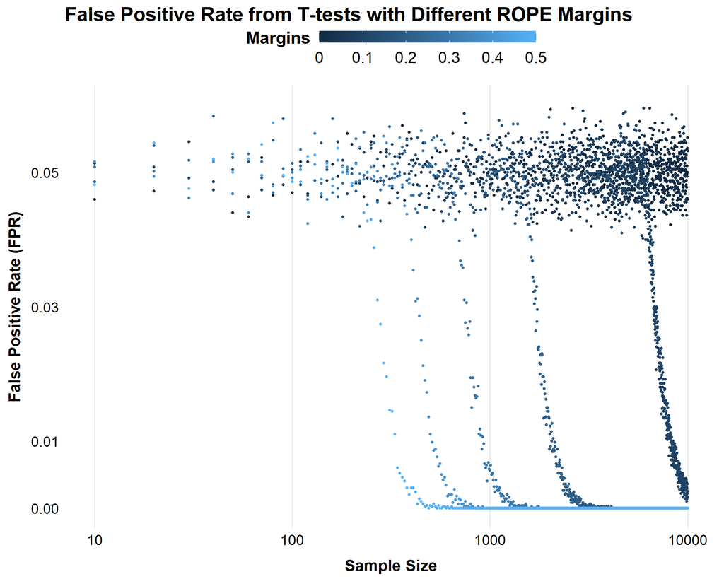

```r
sim_rope_margins |>
  ggplot(aes(x = n, colour = margins, group = margins))+
  geom_point(aes(y = failed), size = 1)+
  scale_x_log10("Sample Size", breaks = c(0, 10, 100, 1000, 10000))+
  scale_y_continuous("False Positive Rate (FPR)", limits = c(0, .06), breaks = c(0, 0.01, 0.03, 0.05))+
  scale_color_gradient("Margins",
                       guide = guide_colourbar(barwidth = 15, barheight = .8, title.vjust = 1),
                       breaks = seq(0, 0.5, 0.1),
                       labels = seq(0, 0.5, 0.1))+
  theme_project_light(base_size = base_size)+
  ggtitle("False Positive Rate from T-tests with Different ROPE Margins")
```

```r
# ggsave(filename = here::here("images", "ch2", "sim_rope.png"), dpi = 360, width = 10, height = 8)
```

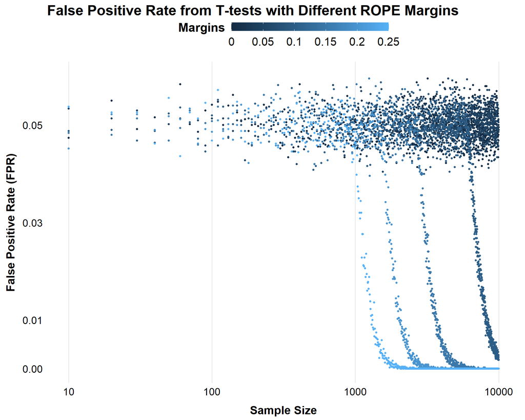

```r
sim_rope_small_margins |>
  ggplot(aes(x = n, colour = margins, group = margins))+
  geom_point(aes(y = failed), size = 1)+
  scale_x_log10("Sample Size", breaks = c(0, 10, 100, 1000, 10000))+
  scale_y_continuous("False Positive Rate (FPR)", limits = c(0, .06), breaks = c(0, 0.01, 0.03, 0.05))+
  scale_color_gradient("Margins",
                       guide = guide_colourbar(barwidth = 15, barheight = .8, title.vjust = 1),
                       breaks = seq(0, 0.25, 0.05),
                       labels = seq(0, 0.25, 0.05))+
  theme_project_light(base_size = base_size)+
  ggtitle("False Positive Rate from T-tests with Different ROPE Margins")
```

```r
# ggsave(filename = here::here("images", "ch2", "sim_rope_small.png"), dpi = 360, width = 10, height = 8)
```

### **Chapter 3.1**: Accumulated False Positive from Sequential t-tests, at different alphas or with different ROPES

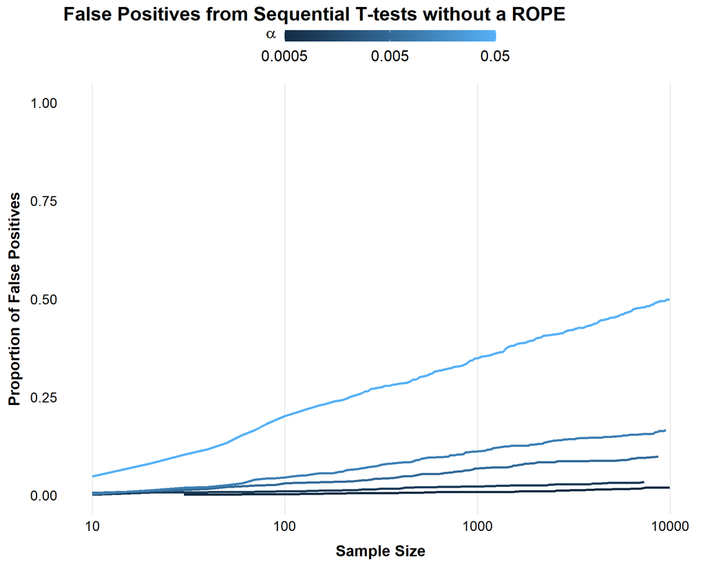

```r
seq_alphas_df |>
  ggplot(aes(x = as.integer(n), y = prop, colour = alpha, group = alpha))+
  geom_line(size = 1.2)+
  scale_x_log10("Sample Size")+
  scale_y_continuous("Proportion of False Positives", limits = 0:1)+
  scale_color_gradient(bquote(alpha),
                       guide = guide_colourbar(barwidth = 15, barheight = .8, title.vjust = 1),
                       trans = "log",
                       breaks = c(0.0005, 0.005, 0.05),
                       labels = c("0.0005", 0.005, 0.05))+
  theme_project_light(base_size = base_size)+
  ggtitle("False Positives from Sequential T-tests without a ROPE")
```

```r
# ggsave(filename = here::here("images", "ch2", "seq_alphas.png"), dpi = 360, width = 10, height = 8)
```

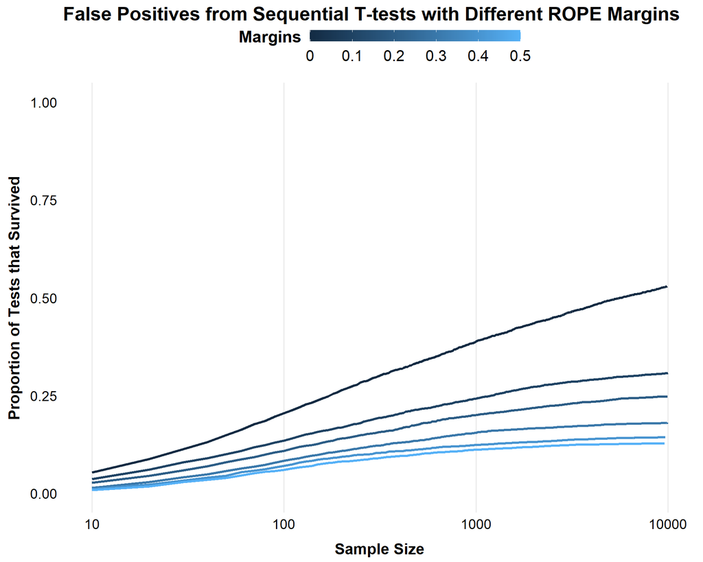

```r
seq_rope_margins_df |>
  na.omit() |>
  ggplot(aes(x = as.integer(n), y = prop, colour = margins, group = margins))+
  geom_line(size = 1.2)+
  scale_x_log10("Sample Size")+
  scale_y_continuous("Proportion of Tests that Survived", limits = 0:1)+
  ggtitle("False Positives from Sequential T-tests with Different ROPE Margins")+
  scale_color_gradient("Margins",
                       guide = guide_colourbar(barwidth = 15, barheight = .8, title.vjust = 1),
                       breaks = seq(0, 0.5, 0.1),
                       labels = seq(0, 0.5, 0.1))+
  theme_project_light(base_size = base_size)
```

```r
# ggsave(filename = here::here("images", "ch2", "seq_rope.png"), dpi = 360, width = 10, height = 8)
```

```r
# seq_t_test_many_alphas_rope_m_df |>
#   na.omit() |>
#   ggplot(aes(x = as.integer(n), y = prop, colour = as.factor(margin), group = margin))+
#   geom_line(size = 1)+
#   scale_x_log10("Sample Size)+
#   scale_y_continuous("Proportion of Tests that Survived", limits = 0:1)+
#   theme_project_light()+
#   ggtitle("False Positives from Sequential t-test with alpha of 0.05, at various ROPE margins")+
#   labs(tag = "Figure 3.1C")
```

### **Chapter 3.2**: Showing the Mean Difference Behind the Significant Results

What may not be apparent from the False positive is the observed difference between to two groups and how the ROPE interacts with that. These graphs are quite nice illustrations of the intuition behind the ROPE, as mean differences smaller than the margins of the ROPES will not cause the sequential t-tests to stop. Even if the p-value is significant, if the mean different is smaller than the rope, the t-tests will continue on the sequential procedure.

These graphs show how the ROPE determines to minimal accepted mean difference that would be interpreted as a significant result, as both the p-value and mean difference satify our criteria of a meaningful difference between the groups (p-value representing the rarity of the difference and the ROPE ensuring our mean differences are not irrelevant).

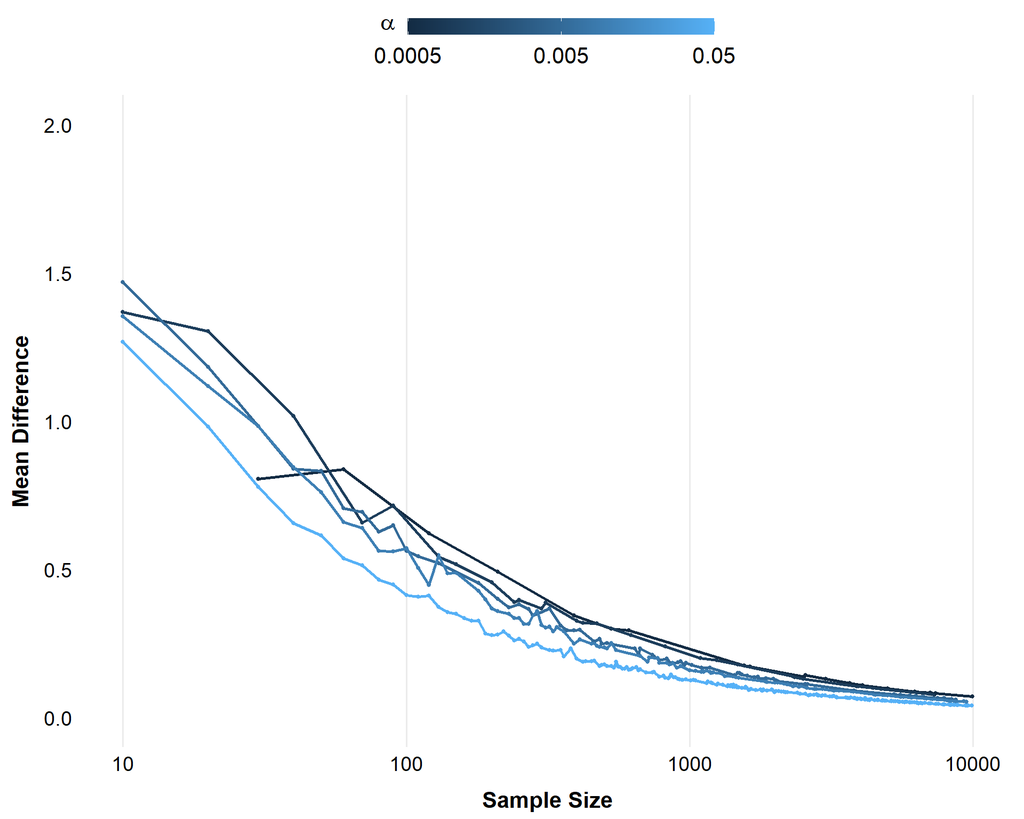

```r
seq_alphas |>
  ggplot(aes(x = as.integer(n), y = mean_diff, colour = alpha, group = alpha))+
  geom_point(size = 1)+
  geom_line(size = 1)+
  scale_x_log10("Sample Size")+
  scale_y_continuous("Mean Difference", limits = c(0,2))+
  theme_project_light(base_size = base_size)+
  scale_color_gradient(bquote(alpha),
                       guide = guide_colourbar(barwidth = 15, barheight = .8, title.vjust = 1),
                       trans = "log",
                       breaks = c(0.0005, 0.005, 0.05),
                       labels = c("0.0005", 0.005, 0.05))
```

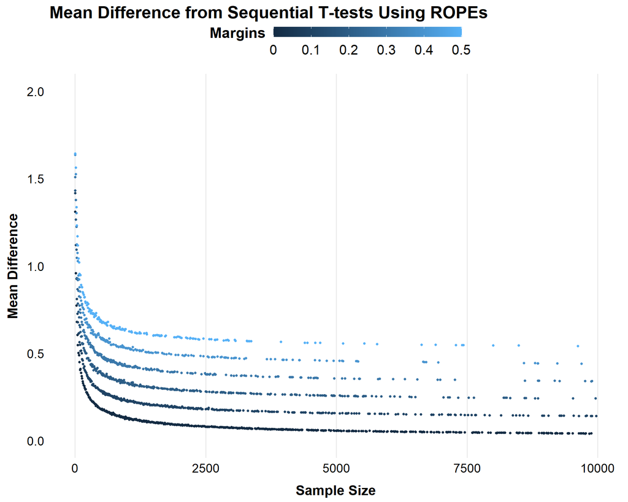

```r
seq_rope_margins |>
  ggplot(aes(x = as.integer(n), y = mean_diff, colour = margins, group = margins))+
  geom_point(size = 1)+
  # geom_line(size = 1)+
  scale_x_continuous("Sample Size")+
  scale_y_continuous("Mean Difference", limits = c(0,2))+
  theme_project_light(base_size = base_size)+
  scale_color_gradient("Margins",
                       guide = guide_colourbar(barwidth = 15, barheight = .8, title.vjust = 1),
                       breaks = seq(0, 0.5, 0.1),
                       labels = seq(0, 0.5, 0.1))+
  labs(title = "Mean Difference from Sequential T-tests Using ROPEs")
```

```r
# ggsave(filename = here::here("images", "ch2", "seq_rope_mean.png"), dpi = 360, width = 10, height = 8)
```

```r
## Both of these files are around 2GB, so using parallel computing to load data in quicker
cores <- parallel::detectCores() - 2

## raw values from simulated t-tests - where NULL is TRUE
sim_raw <- read_csv(file = here::here("sim_data", "ch2_t_tests", "sim_alphas_raw.csv.gz"), num_threads =  cores)
## raw values from simulated t-tests - where NULL is FALSE
sim_diff_raw <- read_csv(file = here::here("sim_data", "ch2_t_tests", "sim_diff_alphas_raw.csv.gz"), num_threads =  cores)
## raw values from simulated t-tests - using different ROPE Margins
sim_margin_raw <- read_csv(file = here::here("sim_data", "ch2_t_tests", "sim_rope_margins_raw.csv"), num_threads =  cores)
sim_small_margin_raw <- read_csv(
  file = here::here("sim_data", "ch2_t_tests", "sim_rope_small_margins_raw.csv.gz"), num_threads =  cores)
# write_csv(x = sim_margin_raw, file = here::here("sim_data", "ch2_t_tests", "sim_rope_amrgins_raw.csv.gz"))
```

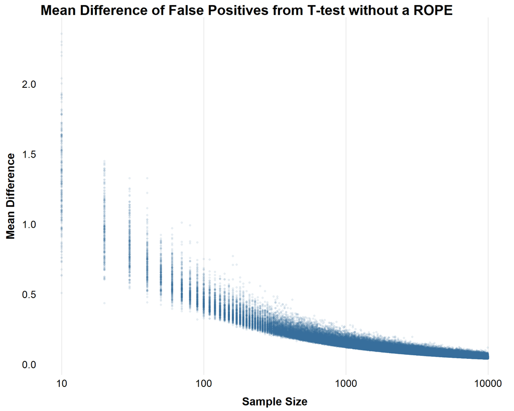

```r
## Only plotting significant results, and showing how mean diff decreases as N increases when the Null is true.
## Closely resembles the critical effect curve (naturally)

sim_raw |>
  filter(p < alpha, alpha == 0.05) |>
  ggplot(aes(x = n, y = mean_diff, group = alpha, colour = alpha))+
  geom_point(alpha = .1, size = 1, show.legend = F)+
  scale_x_log10("Sample Size", breaks = c(10, 100, 1000, 10000))+
  scale_y_continuous("Mean Difference")+
  theme_project_light(base_size = base_size)+
  labs(title = "Mean Difference of False Positives from T-test without a ROPE")
```

```r
# ggsave(filename = here::here("images", "ch2", "sim_alpha_mean.png"), dpi = 360, width = 10, height = 8)
```

```r
## consistency when there is an effect - nice to show both sides of consistency - when Null is false (mean difference of 0.5)
# sim_diff_raw |>
#   filter(p < alpha, alpha == 0.05) |>
#   ggplot(aes(x = n, y = mean_diff, group = alpha, colour = alpha))+
#   geom_point(alpha = .1, size = .2)+
#   theme_project_light(base_size = base_size)
```

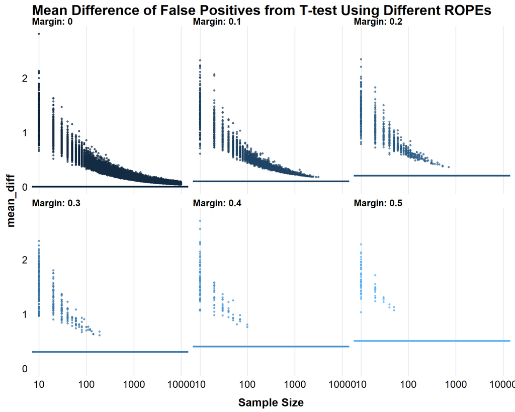

```r
## significant when CI is outside the Margin
sim_margin_raw |>
  select(!n) |>
  mutate(n = rep(2*n, times = 6 * 5000))  |>
  filter(p < 0.05, l_ci > margins | u_ci < -margins) |>
  ggplot(aes(x = n, y = mean_diff, group = margins, colour = margins))+
  geom_point(alpha = .7, size = 1, show.legend = F)+
  geom_hline(aes(yintercept = margins, colour = margins), show.legend = F, linewidth = 1.2)+
  facet_wrap(~margins, labeller = as_labeller(function(x)  paste("Margin: ", as.character(x), sep = "")))+
  scale_x_log10("Sample Size", breaks = c(10, 100, 1000, 10000))+
  theme_project_light(base_size = base_size)+
  theme(strip.text = element_text(vjust = 1))+
  labs(title = "Mean Difference of False Positives from T-test Using Different ROPEs")
```

```r
# ggsave(filename = here::here("images", "ch2", "sim_rope_mean.png"), dpi = 360, width = 10, height = 8)
```

```r
## Plotting only the points that are completely inside the ROPE
sim_margin_raw |>
  select(!n) |>
  mutate(n = rep(2*n, times = 6 * 5000))  |>
  filter(p < 0.05, l_ci > -margins & u_ci < margins) |>
  ggplot(aes(x = n, y = mean_diff, group = margins, colour = margins))+
  geom_point(alpha = .2, size = .4, show.legend = F)+
  geom_hline(aes(yintercept = margins, colour = margins), show.legend = F, linewidth = 1.2)+
  facet_wrap(~margins, labeller = as_labeller(function(x)  paste("Margin :", as.character(x), sep = "")))+
  scale_x_log10("Sample Size", breaks = c(10, 100, 1000, 10000), limits = c(10, 10000))+
  scale_y_continuous(limits = c(0, .5))+
  theme_project_light(base_size = base_size)+
  theme(strip.text = element_text(vjust = 1))
```

[output not shown]

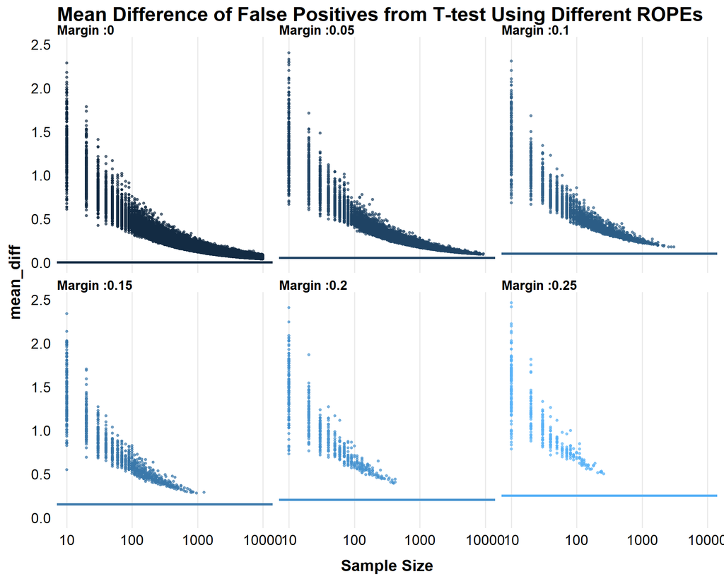

```r
## significant when CI is outside the Margin
sim_small_margin_raw |>
  filter(p < 0.05, l_ci > margins | u_ci < -margins) |>
  ggplot(aes(x = n, y = mean_diff, group = margins, colour = margins))+
  geom_point(alpha = .7, size = 1, show.legend = F)+
  geom_hline(aes(yintercept = margins, colour = margins), show.legend = F, linewidth = 1.2)+
  facet_wrap(~margins, labeller = as_labeller(function(x)  paste("Margin :", as.character(x), sep = "")))+
  scale_x_log10("Sample Size", breaks = c(0, 10, 100, 1000, 10000))+
  theme_project_light(base_size = base_size)+
  theme(strip.text = element_text(vjust = 1))+
  labs(title = "Mean Difference of False Positives from T-test Using Different ROPEs")
```

```r
# ggsave(filename = here::here("images", "ch2", "sim_small_rope_mean.png"), dpi = 360, width = 10, height = 8)
```

```r
## Plotting only the points that are completely inside the ROPE
sim_small_margin_raw |>
  filter(p < 0.05, l_ci > -margins & u_ci < margins) |>
  ggplot(aes(x = n, y = mean_diff, group = margins, colour = margins))+
  geom_point(alpha = .2, size = .4, show.legend = F)+
  geom_hline(aes(yintercept = margins, colour = margins), linewidth = 1.2, show.legend = F)+
  facet_wrap(~margins, labeller = as_labeller(function(x)  paste("Margin :", as.character(x), sep = "")))+
  scale_x_log10("Sample Size", breaks = c(0, 10, 100, 1000, 10000), limits = c(10, 10000))+
  scale_y_continuous(limits = c(0, .5))+
  theme_project_light(base_size = base_size)+
  theme(strip.text = element_text(vjust = 1))
```

[output not shown]

```r
# seq_rope_alphas |>
#   filter(p < alpha) |>
#   ggplot(aes(x = as.integer(n), y = mean_diff, colour = alpha, group = alpha))+
#   geom_point(size = 1)+
#   geom_line(size = 1)+
#   scale_x_log10("Sample Size)+
#   scale_y_continuous("Mean Difference", limits = c(0,2))+
#   theme_project_light()+
#   labs(tag = "Figure 3.2A")
```

### **Chapter 4.1**: Comparing Graphs when there is no ROPE - reading in data

```r
# seq_t_test_many_alphas <- read_csv(file = here::here("sim_data","seq_t_test_many_alphas.csv"), col_types = "ifi?")
#
# head(seq_t_test_many_alphas)
```

```r
# seq_t_test_many_alphas_mean <-
#   read_csv(file = here::here("sim_data","seq_t_test_many_alphas_mean_break.csv"), show_col_types = F)
#   # select(1, 2, 5:8) # the other columns are not necessary here ??
#
# head(seq_t_test_many_alphas_mean)
```

### **Chapter 4.2**: Accumulated False Positive from Sequential t-tests, at different alphas with no ROPE

```r
# seq_t_test_many_alphas |>
#   ggplot(aes(x = n, y = pval, colour = alpha))+
#   geom_line(aes(x = n, y = 1 - prop), size = 1, alpha = 0.7)+
#   scale_x_log10("Sample Size")+
#   scale_y_continuous("Proportion of Tests that Survived")+
#   ggtitle("False Positives from Sequential t-test at Various Alpha Levels, with no ROPE")+
#   theme_project_light()
```

### **Chapter 4.3**: Showing the Mean Difference Behind Significant Results, at different alphas with no ROPE

```r
# seq_t_test_many_alphas_mean |>
#   filter(alpha == 0.05) |>
#   ggplot(aes(x = n, y = mean_diff))+
#   geom_point(size = 1, alpha = .2, colour = "blue")+
#   geom_ribbon(aes(ymin = mean_diff_mean - mean_diff_sd,
#                   ymax = mean_diff_mean + mean_diff_sd),
#               alpha = .4, fill = "lightblue")+
#   geom_line(aes(x = n, y = mean_diff_mean),
#             stat = "smooth",
#             size = 1, colour = "darkblue", alpha = .6)+
#   theme_project_light()+
#   scale_x_log10("Sample Size")+
#   scale_y_continuous("Absolute Mean Difference")+
#   ggtitle("Mean Difference of Significant results at different sample sizes, Alpha = 0.05")+
#   coord_cartesian(expand = T)
```

```r
# seq_t_test_many_alphas_mean |>
#   ggplot(aes(x = n, y = mean_diff, colour = as.factor(alpha)))+
#   geom_point(size = 1, alpha = .2)+
#   geom_line(aes(y = mean_diff_mean),stat = "smooth",  size = 1, alpha = .4, se = F)+
#   theme_project_light()+
#   scale_x_log10("Sample Size")+
#   scale_y_continuous("Absolute Mean Difference")+
#   ggtitle("Mean Difference of Significant results at different sample sizes (for different alphas)")
```